# Situation-dependent changes of behavior towards waste disposal

Author

Charlotte Meyer

Published

June 25, 2024

# Introduction

Throwing out plastic bottles, cans, packaging, and so on is a common part of our daily life, and is influenced by multiple factors. Previous studies investigated the impact of knowldege (Babaei et al. (2015)), socio-demographic factors (Chikowore (2021)), as well as uncommon situation such as the COVID-19 pandemic (Yousefi et al. (2021)) on waste disposal behavior. However, studies linking the behavior of an individual within specific environments are limited. In this context, the present study investigates the potential change of behavior amongst students at ETH Zürich in the three following scenarios: waste disposal with a time constraint, after an afternoon at the Limmat, and during a hike.

# Methods

The data was collected through a survey containing 18 questions. The questionnaire was divided in 6 parts, namely demographics, waste disposal habits, scenario 1, scenario 2, scenario 3, and reflection. In the scenario 1, the questions were related to changes in waste disposal behavior in case of a time constraint. In scenario 2, the participants had to imagine their behavior towards waste disposal after an afternoon at the Limmat. Scenario 3 contained questions related to waste disposal during a hike. 19 ETH Zürich students participated to the survey.

# Results

In the scenario 1, the behavior towards waste disposal after adding a time constaint was investigated for different pursued degrees. In Figure 1, the likelihood between 1 and 5 that the participants would change their behavior towards not recycling their waste if there is a time constraint was analysed. Amongst the participants who would recycle the waste from their lunch, a majority are rather likely to not recycle anymore if there is a time constraint due to an imminent lecture or meeting.

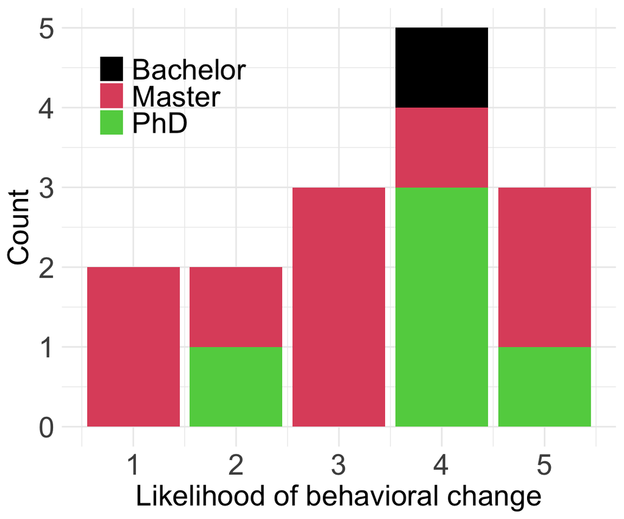

Figure 1: Likelihood of behavioral change in a time-contrained situation

```r
# load libraries and data ------------------------------

library(readr)
library(tidyverse)
library(ggplot2)
library(ggthemes)
library(gt)


waste_disposal_behavior <- read_csv(here::here("data/processed/influence_environment_behavior_waste_disposal_processed.csv"))

# data analysis ---------------------------------------

waste_disposal_behavior_fig1 <- waste_disposal_behavior |>
  filter(lunch_recycling_yesno == "Yes") |>
  select(current_degree, lunch_recycling_littleTime)

# results display as figure ---------------------------

ggplot(data=waste_disposal_behavior_fig1,
       mapping=aes(x=lunch_recycling_littleTime, fill=current_degree)) +
  geom_bar() +
  scale_fill_manual(values=palette("Set2")) +
  labs(x="Likelihood of behavioral change",
       y="Count") +
   theme_minimal() +
   theme(title=element_text(size=20),
        axis.title.x=element_text(size=20),
        axis.title.y=element_text(size=20),
        axis.text=element_text(size=20),
        legend.position=c(0.2,0.8),
        legend.text=element_text(size=20),
        legend.title=element_blank())

# save data underlying the figure ----------------------

write_csv(waste_disposal_behavior_fig1, here::here("data/final/fig1_time_constraint.csv"))
```

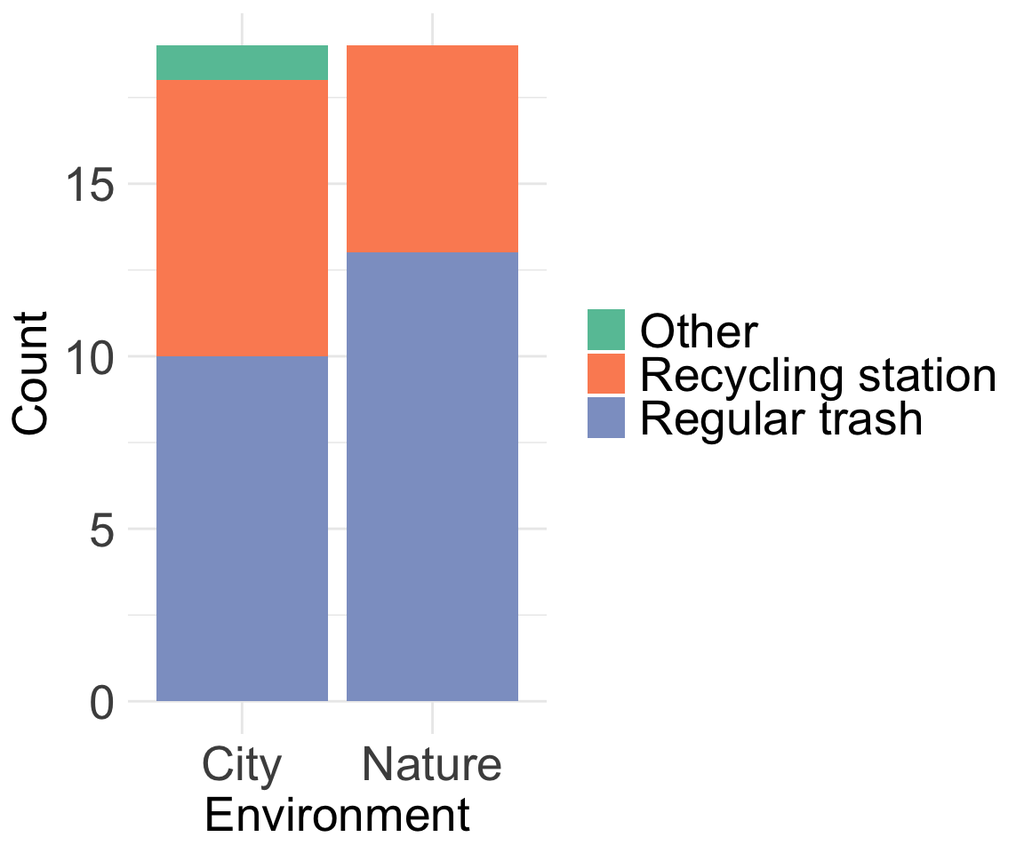

Figure 2: Comparison of waste disposal location when in nature or in the city

```r
# data analysis ---------------------------------------

waste_disposal_behavior_fig2 <- waste_disposal_behavior |>
  pivot_longer(cols = c(hike_recycling_location, limmat_recycling_location),
               names_to = "environment",
               values_to = "recycling_location") |>
  mutate(nature_vs_city = factor(case_when(
         environment == "hike_recycling_location" ~ "Nature",
         environment == "limmat_recycling_location" ~ "City",
         .default = "Other"
     ))) |>
  mutate(trash_type = case_when(
         recycling_location == "Proper recycling in Zürich or at home" ~ "Recycling station",
         recycling_location == "Regular trash at the car or at the closest train station" ~ "Regular trash",
         recycling_location == "Leaving everything in nature" ~ "Left behind",
         recycling_location == "Leaving everything there on the grass" ~ "Left behind",
         recycling_location == "Closest regular trash at the Limmat" ~ "Regular trash",
         recycling_location == "Proper recycling station a bit further" ~ "Recycling station",
        .default = "Other"
     )) |>
  select(nature_vs_city, trash_type)

# results display as figure ---------------------------

ggplot(data=waste_disposal_behavior_fig2,
       mapping=aes(x=nature_vs_city, fill=trash_type)) +
  geom_bar() +
  scale_fill_manual(values=palette("Set2")) +
  labs(x="Environment",
       y="Count") +
   theme_minimal() +
   theme(title=element_text(size=20),
        axis.title.x=element_text(size=20),
        axis.title.y=element_text(size=20),
        axis.text=element_text(size=20),
        legend.text=element_text(size=20),
        legend.title=element_blank())

# save data underlying the figure ----------------------

write_csv(waste_disposal_behavior_fig2, here::here("data/final/fig1_nature_vs_city.csv"))
```

Table 1 shows a comparison between the self-evaluated waste disposal behavior of the participants on a scale from 1 (bad) to 5 (good) at the beginning and at the end of the survey grouped by age range. For the participants between 18 to 24 years old, the means are slightly lower, while the participants between 25 and 30 years old showed a slight increase. This suggests a decrease or reinforcement, respectively, of appreciation in their waste disposal behavior. The participant between 31 and 35 years old had no variation between the start and the end of the survey.

```r
# data analysis ---------------------------------------

waste_disposal_behavior_tbl <- waste_disposal_behavior |>
  group_by(age_range) |>
  summarise(mean_start = mean(recycling_habits_start),
            sd_start = sd(recycling_habits_start),
            mean_end = mean(recycling_habits_end),
            sd_end = sd(recycling_habits_end),
            n = n())

# results display as table ---------------------------

waste_disposal_behavior_tbl |>
    gt() |>
  fmt_number(-n, decimals = 2) |>
    cols_label(age_range = "Age",
               mean_start = "Mean at start",
               sd_start = "SD at start",
               mean_end = "Mean at end",
               sd_end = "SD at end") |>
  tab_options(
    data_row.padding = px(3),
    column_labels.background.color = "#A2D1CC"
  )
# save data underlying the table ----------------------

write_csv(waste_disposal_behavior_tbl, here::here("data/final/tbl_habits_start_end_survey.csv"))
```

Table 1: Mean values for evaluation of behavior towards waste disposal at the start and at the end of the survey

| Age | Mean at start | SD at start | Mean at end | SD at end | n |
| --- | --- | --- | --- | --- | --- |
| 18-21 | 4.00 | NA | 3.00 | NA | 1 |
| 22-24 | 3.43 | 0.53 | 3.14 | 0.38 | 7 |
| 25-30 | 3.70 | 0.48 | 3.80 | 0.63 | 10 |
| 31-35 | 1.00 | NA | 1.00 | NA | 1 |

# Conclusions

# References

Babaei, A. A., Alavi, N., Goudarzi, G., Teymouri, P., Ahmadi, K., & Rafiee, M. (2015). Household recycling knowledge, attitudes and practices towards solid waste management. *Resources, Conservation and Recycling*, *102*, 94–100. https://doi.org/10.1016/j.resconrec.2015.06.014

Chikowore, N. (2021). Factors influencing household waste management practices in Zimbabwe. *Journal of Material Cycles and Waste Management*, *23*(1), 386–393. https://doi.org/10.1007/s10163-020-01129-9

Yousefi, M., Oskoei, V., Jonidi Jafari, A., Farzadkia, M., Hasham Firooz, M., Abdollahinejad, B., & Torkashvand, J. (2021). Municipal solid waste management during COVID-19 pandemic: Effects and repercussions. *Environmental Science and Pollution Research*, *28*(25), 32200–32209. https://doi.org/10.1007/s11356-021-14214-9